# Analysis of miRNA-Seq data for the Henderson lab

James W. MacDonald

27 January 2020

# 1 Introduction

This is an analysis of miRNA-Seq data from subjects with uticaria who were treated with omalizumab in three monthly injections. The subjects were grouped according to their UAS7 itch score into complete responders and non-responders, and the goal is to detect miRNA transcripts that change according to the outcome, as well as correlate the miRNA transcripts with other phenotypic results.

Blood was drawn from each subject at baseline, approximately 14 days later, and again approximately 90 days later. Both exosomes and basophils were extracted and assayed for miRNA transcript abundances using Qiagen’s QIAseq UMI method. Samples and timepoints for this analysis are presented below.

**Please note that this is an updated version of the analysis, after removing Subject 16. Also note that this document is truncated; previously it included miRNA-mRNA correlation analyses that are not being used, so we removed that portion.**

Samples used in this analysis.

| Subject | Day | Outcome | AdjDay |
| --- | --- | --- | --- |
| 1 | Day 1 baseline | CR | Day1 |
| 1 | Day 15 | CR | Day14 |
| 1 | Day 87 | CR | Day90 |
| 3 | Day 1 baseline | NR | Day1 |
| 3 | Day 15 | NR | Day14 |
| 3 | Day 86 | NR | Day90 |
| 8 | Day 1 baseline | CR | Day1 |
| 8 | Day 15 | CR | Day14 |
| 8 | Day 87 | CR | Day90 |
| 9 | Day 1 baseline | NR | Day1 |
| 9 | Day 14 | NR | Day14 |
| 9 | Day 84 | NR | Day90 |
| 10 | Day 1 baseline | CR | Day1 |
| 10 | Day 17 | CR | Day14 |
| 10 | Day 80 | CR | Day90 |
| 11 | Day 1 baseline | NR | Day1 |
| 11 | Day 15 | NR | Day14 |
| 11 | Day 85 | NR | Day90 |
| 12 | Day 1 baseline | CR | Day1 |
| 12 | Day 14 | CR | Day14 |
| 12 | Day 84 | CR | Day90 |
| 17 | Day 1 baseline | CR | Day1 |
| 17 | Day 14 | CR | Day14 |
| 17 | Day 92 | CR | Day90 |
| 24 | Day 1 baseline | NR | Day1 |
| 24 | Day 15 | NR | Day14 |
| 24 | Day85 | NR | Day90 |
| 25 | Day 1 baseline | CR | Day1 |
| 25 | Day 15 | CR | Day14 |
| 25 | Day85 | CR | Day90 |

The actual day of the blood draw is approximately 14 and 90 days; we converted all the actual days to an adjusted day of 14 and 90 for linear modeling.

# 2 Exploratory data analysis

We first present a table of read depth for each sample, by type.

Library depth and sample weights for basophil samples. The counts column presents the total UMI counts per sample (in millions), and the weights are used in the linear modeling step (see below).

| Subject | Outcome | AdjDay | Counts | Weights |
| --- | --- | --- | --- | --- |
| 1 | CR | Day1 | 4.14 | 0.33 |
| 1 | CR | Day14 | 3.57 | 0.66 |
| 1 | CR | Day90 | 3.12 | 1.29 |
| 3 | NR | Day1 | 3.24 | 1.37 |
| 3 | NR | Day14 | 3.16 | 1.36 |
| 3 | NR | Day90 | 3.06 | 1.17 |
| 8 | CR | Day1 | 2.64 | 0.97 |
| 8 | CR | Day14 | 2.83 | 0.91 |
| 8 | CR | Day90 | 1.81 | 1.74 |
| 9 | NR | Day1 | 2.66 | 1.45 |
| 9 | NR | Day14 | 2.84 | 1.15 |
| 9 | NR | Day90 | 2.14 | 2.09 |
| 10 | CR | Day1 | 3.08 | 1.53 |
| 10 | CR | Day14 | 2.37 | 1.27 |
| 10 | CR | Day90 | 2.42 | 0.99 |
| 11 | NR | Day1 | 2.44 | 1.04 |
| 11 | NR | Day14 | 2.31 | 1.34 |
| 11 | NR | Day90 | 1.85 | 1.81 |
| 12 | CR | Day1 | 2.71 | 1.07 |
| 12 | CR | Day14 | 2.45 | 1.93 |
| 12 | CR | Day90 | 2.68 | 1.60 |
| 17 | CR | Day1 | 3.10 | 1.77 |
| 17 | CR | Day14 | 2.90 | 1.45 |
| 17 | CR | Day90 | 1.36 | 0.64 |
| 24 | NR | Day1 | 1.58 | 0.26 |
| 24 | NR | Day14 | 2.92 | 0.36 |
| 24 | NR | Day90 | 3.37 | 0.12 |
| 25 | CR | Day1 | 2.45 | 0.83 |
| 25 | CR | Day14 | 2.70 | 0.76 |
| 25 | CR | Day90 | 2.90 | 1.62 |

In the above table we present the total UMI counts (in millions). We have somewhere between 1.5 - 4 million UMI counts, which is a reasonable library depth. By using UMI counts rather than raw counts we are able to distinguish unique miRNA transcript counts from PCR duplicates, which helps reduce any bias.

Library depth and sample weights for exosome samples. The counts column presents the total UMI counts per sample (in millions), and the weights are used in the linear modeling step (see below).

| Subject | Outcome | AdjDay | Counts | Weights |
| --- | --- | --- | --- | --- |
| 1 | CR | Day1 | 1.56 | 0.86 |
| 1 | CR | Day14 | 0.91 | 0.48 |
| 1 | CR | Day90 | 0.81 | 1.08 |
| 3 | NR | Day1 | 1.07 | 1.04 |
| 3 | NR | Day14 | 0.84 | 0.64 |
| 3 | NR | Day90 | 0.72 | 0.55 |
| 8 | CR | Day1 | 0.94 | 1.43 |
| 8 | CR | Day14 | 0.92 | 1.01 |
| 8 | CR | Day90 | 0.80 | 1.09 |
| 9 | NR | Day1 | 1.17 | 1.46 |
| 9 | NR | Day14 | 1.08 | 1.83 |
| 9 | NR | Day90 | 1.28 | 1.09 |
| 10 | CR | Day1 | 1.10 | 0.98 |
| 10 | CR | Day14 | 1.04 | 1.57 |
| 10 | CR | Day90 | 1.18 | 1.01 |
| 11 | NR | Day1 | 1.00 | 1.36 |
| 11 | NR | Day14 | 1.13 | 1.12 |
| 11 | NR | Day90 | 1.17 | 1.80 |
| 12 | CR | Day1 | 0.95 | 1.56 |
| 12 | CR | Day14 | 1.05 | 1.65 |
| 12 | CR | Day90 | 0.96 | 1.41 |
| 17 | CR | Day1 | 1.24 | 0.85 |
| 17 | CR | Day14 | 1.11 | 1.17 |
| 17 | CR | Day90 | 1.01 | 1.17 |
| 24 | NR | Day1 | 1.09 | 1.12 |
| 24 | NR | Day14 | 2.05 | 0.73 |
| 24 | NR | Day90 | 2.12 | 0.56 |
| 25 | CR | Day1 | 1.70 | 0.62 |
| 25 | CR | Day14 | 1.73 | 0.47 |
| 25 | CR | Day90 | 2.18 | 0.56 |

We get smaller library sizes for the exosome samples, somewhere between 0.8 - 2M UMI reads.

# 3 Model fit and results

To make these comparisons we use the Bioconductor edgeR and limma packages. Count data are not amenable to analysis using conventional linear regression because they are not normally distributed and have a strong dependence between the mean and variance. However, we can normalize to account for differences in library size (compute counts/million), and then convert to log<sub>2</sub> (logCPM), which will make the distribution of the data closer to a normal distribution. We can then compute observation-level weights, based on the mean-variance trend of the logCPM values and fit a weighted linear model. This is called a limma-voom transformation (Law et al. 2014). As part of the weight estimation we can also compute sample-specific weights based on how similar (or different) each sample is to others of the same type (Liu et al. 2015), which has been shown to improve power in both real and simulated data sets.

By using conventional linear models we are also able to fit a linear mixed model, which allows us to account for the intra-subject correlation that occurs when we make repeated measures of each subject. We fit the weighted linear mixed model, and then computed empirical Bayes adjusted contrasts (Phipson et al. 2016) to test for differences between various time/outcome groups. We selected miRNA transcripts using a false discovery rate (FDR) of 0.1, meaning that we expect at most to have 10% false positives in the set of significant genes.

Number of significant genes for exosomes at an FDR < 0.1.

| Comparison | Number significant |
| --- | --- |
| CR Day1 vs NR Day1 | 17 |
| CR Day14 vs NR Day14 | 31 |
| CR Day90 vs NR Day90 | 10 |
| CR Day1 vs CR Day14 | 6 |
| CR Day1 vs CR Day90 | 19 |
| CR Day14 vs CR Day90 | 17 |
| NR Day1 vs NR Day14 | 57 |
| NR Day1 vs NR Day90 | 44 |
| NR Day14 vs NR Day90 | 34 |

The links in the above table will open an interactive document containing the results. At the top left is an MA plot, which shows the average logCPM (roughly the average expression level of the miRNA) on the horizontal axis, and the log fold change between the two groups on the vertical axis. Any differentially expressed gene will be colored red. If you hover over any plotting symbol, it will bring up a tooltip that shows some information about the gene represented by that point, as well as showing the logCPM values for all the samples in a plot to the top right.

Below the plots is a table, which can be sorted by clicking on any column header. By default it only shows 10 rows, but you can adjust that using the drop-down to the top left of the table. You can also search for anything in that table using the search box on the top right. If you click on any row, it will highlight the corresponding value in the top left plot as well as showing the expression levels in the top right plot.

Number of significant genes for basophils at an FDR < 0.1.

| Comparison | Number significant |
| --- | --- |
| CR Day1 vs NR Day1 | 6 |
| CR Day14 vs NR Day14 | 0 |
| CR Day90 vs NR Day90 | 22 |
| CR Day1 vs CR Day14 | 7 |
| CR Day1 vs CR Day90 | 1 |
| CR Day14 vs CR Day90 | 1 |
| NR Day1 vs NR Day14 | 7 |
| NR Day1 vs NR Day90 | 15 |
| NR Day14 vs NR Day90 | 11 |

## 3.1 UAS7 score over time, stratified by miRNA expression

We can plot the relationship between UAS7 score and time, where we stratify by the underlying miRNA expression for those miRNAs that are differentially expressed at baseline. In other words, for each miRNA that is differentially expressed at baseline, we characterize each subject as having high or low expression (based on being higher or lower than the median expression level for that miRNA), and then plot the relationship between UAS7 score and time for each group of subjects. There are six differentially expressed miRNAs for the basophil samples, so we start with those data.

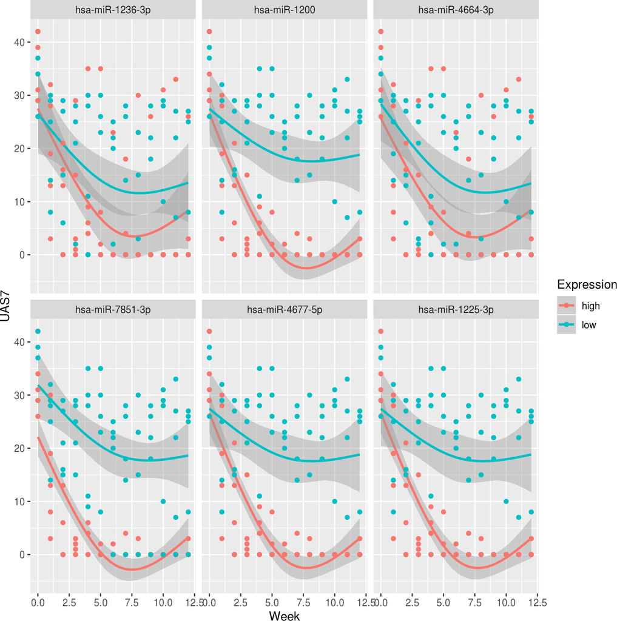

Figure 1: UAS7 score versus time, stratified by miRNA expression levels in basophils  
For each miRNA we classify the subject as high or low, based on the miRNA expression level at baseline. We then plot the relationship between UAS7 and time, stratified by the dichotimized miRNA expression level.

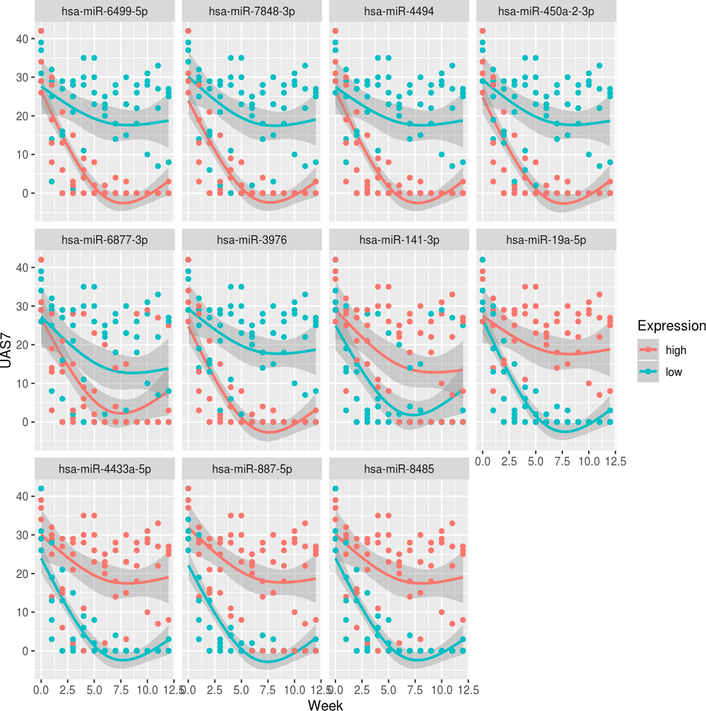

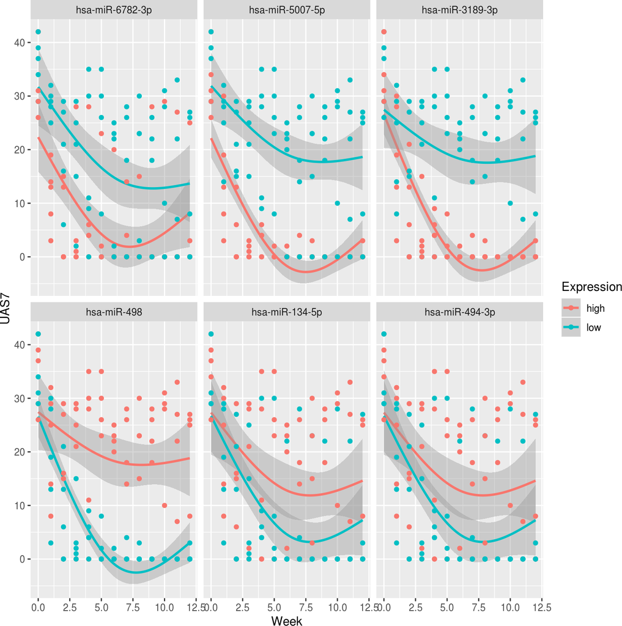

Please note that there is some circularity to the logic behind these plots. We chose these miRNA transcripts because they are different between the CR and NR subjects, which were defined according to the UAS7 score. We then use the miRNA transcripts to re-define the subjects, but since the miRNA transcripts were selected using a classification based on the UAS7 score, it is not unexpected that these plots would then show a difference between UAS7 scores by time.

## 3.2 Relationship between miRNA expression and UAS7 score

We can model miRNA expression as a function of UAS7 score, to see if there is a correlation between the two. To do this, we fit a model that includes a patient-level blocking factor to account for patient-specific miRNA expression levels. We also fit an interaction between miRNA expression and outcome status, which basically means that we plot two lines, one for the CR and one for the NR patients.

We present an example plot, below.

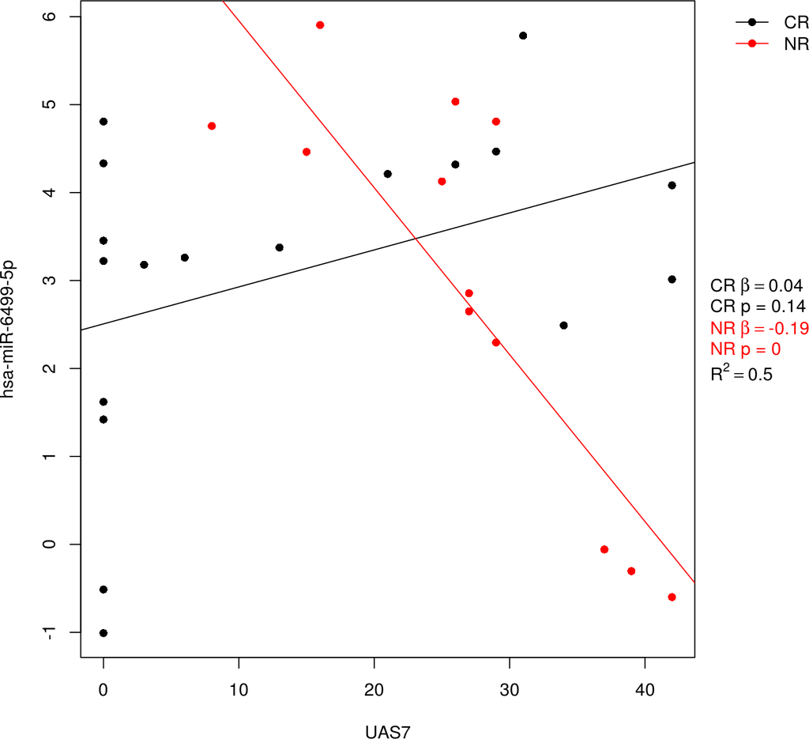

Figure 2: Plot of linear relationship between hsa-miR-6499-5p and UAS7 score, by outcome  
The black points and line are the CR subject observations and regression line, and the red line and points are the NR subjects and regression line. On the right side of the plot are the coefficients and p-values for each regression line, plus the model coefficient of determination. The coefficients can be interpreted as the log change in miRNA expression for every unit change in UAS7. In this plot, the coefficient for the NR group is -0.19, so we can say that for a change in UAS7 of about 5 for that group, we expect the miRNA expression to go down by about half. In other words, for a unit change in UAS7, we expect the miRNA expression to go down by 0.19, so for a change in 5 on UAS7, we expect the miRNA expression to go down by about 1 (-0.19 * 5 is almost 1) and since the miRNA expression is on the log scale, this corresponds to a 50% reduction on the linear scale. The p-value for the CR group tests for evidence that the slope of the line is different from zero (e.g., there is evidence for a change in miRNA expression as UAS7 changes). The p-value for the NR group is slightly different; we are testing for evidence that the slope for the NR group is different than the slope for the CR group. In this example, the NR p-value is < 0.01, and we cannot say that he slope of the CR is not zero, so we have evidence that this miRNA changes expression as UAS7 varies. The coefficient of determination indicates how much of the variability is explained by the regression lines, in this case 50%. We should also point out that the NR fit may be affected by three high-leverage points in the lower right of the plot. Without those three observations, the NR line would be almost the same as the CR line. Whether or not this matters depends on how representative of the underlying population those three subjects are.

We output PDF versions of the above plot, for each contrast and each sample type, which are accessible using the links, below. We also output a set of plots where we only fit one regression line, in the second table below.

Links to plots for each contrast, for each sample type.

| exosomes | basophils |
| --- | --- |
| CR Day1 vs NR Day1 | CR Day1 vs NR Day1 |
| CR Day14 vs NR Day14 | CR Day14 vs NR Day14 |
| CR Day90 vs NR Day90 | CR Day90 vs NR Day90 |
| CR Day1 vs CR Day14 | CR Day1 vs CR Day14 |
| CR Day1 vs CR Day90 | CR Day1 vs CR Day90 |
| CR Day14 vs CR Day90 | CR Day14 vs CR Day90 |
| NR Day1 vs NR Day14 | NR Day1 vs NR Day14 |
| NR Day1 vs NR Day90 | NR Day1 vs NR Day90 |
| NR Day14 vs NR Day90 | NR Day14 vs NR Day90 |

Links to plots for each contrast, for each sample type, one regression line.

| exosomes | basophils |
| --- | --- |
| CR Day1 vs NR Day1 | CR Day1 vs NR Day1 |
| CR Day14 vs NR Day14 | CR Day14 vs NR Day14 |
| CR Day90 vs NR Day90 | CR Day90 vs NR Day90 |
| CR Day1 vs CR Day14 | CR Day1 vs CR Day14 |
| CR Day1 vs CR Day90 | CR Day1 vs CR Day90 |
| CR Day14 vs CR Day90 | CR Day14 vs CR Day90 |
| NR Day1 vs NR Day14 | NR Day1 vs NR Day14 |
| NR Day1 vs NR Day90 | NR Day1 vs NR Day90 |
| NR Day14 vs NR Day90 | NR Day14 vs NR Day90 |

## 3.3 Heatmap of all data

For heatmaps, we generally convert the data to z-scores (e.g., center and scale the data to have a mean of zero and a standard deviation of 1). If we plot the logCPM values directly, the high and low expressing miRNAs will dominate the plot, and may obscure the changes within each miRNA. By using z-scores, the colors within each row can be interpreted as the divergence of a given sample from the mean expression (in units of standard deviations). While this is more difficult to interpret on a row-wise basis, the overall pattern of the heatmap is more interpretable.

The ordering of the columns and rows of a heatmap are usually dictated by a hierarchical clustering of the samples (for the columns) and the miRNAs (for the rows), where the hierarchical clustering attempts to group samples and genes based on how similar they are. Since we already know that we have two groups and three time points, it is not that useful to cluster the columns, so we only cluster the rows. Given the number of transcripts being measured, it’s not easy to make the row names visible, so we omit those for these plots. But do note that we can make a very tall pdf version with which you can see the row names if desired.

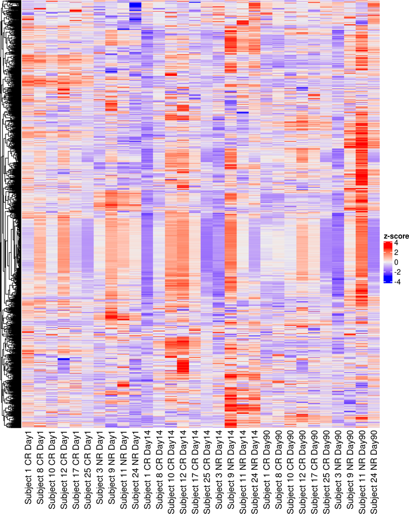

Figure 3: Heatmap of exosome data using z-scores  
The colors for each cell of the heatmap indicate how different that sample is, as compared to the average of all samples for that miRNA transcript. Generally, if there is a consistent pattern of differential expression between groups, it would be clearly visible in this plot.

In this plot there are very few discernable patterns, which should be expected given that we only have a few miRNA transcripts that are differentially expressed. An alternative is to plot only those miRNA transcripts that are differentially expressed in any contrast.

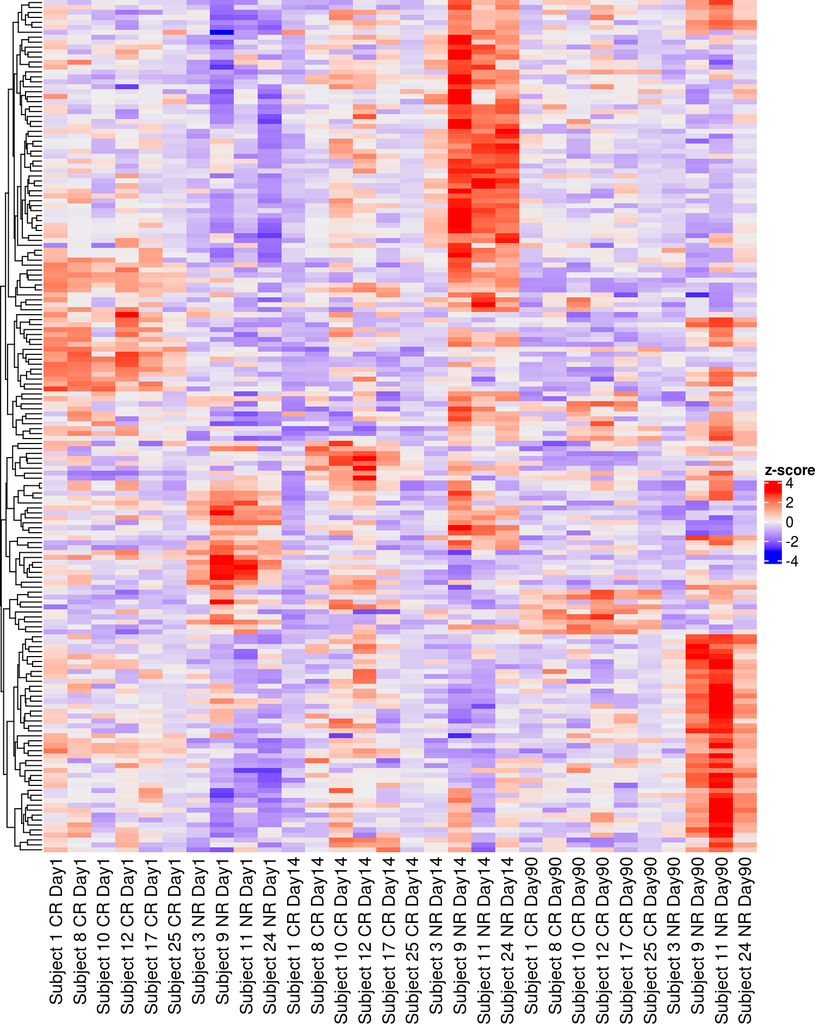

Figure 4: Heatmap of exosome data using z-scores, significant genes only  
When we subset to just the miRNAs that are significant in one or more contrasts, it is easier to see patterns of differential expression.

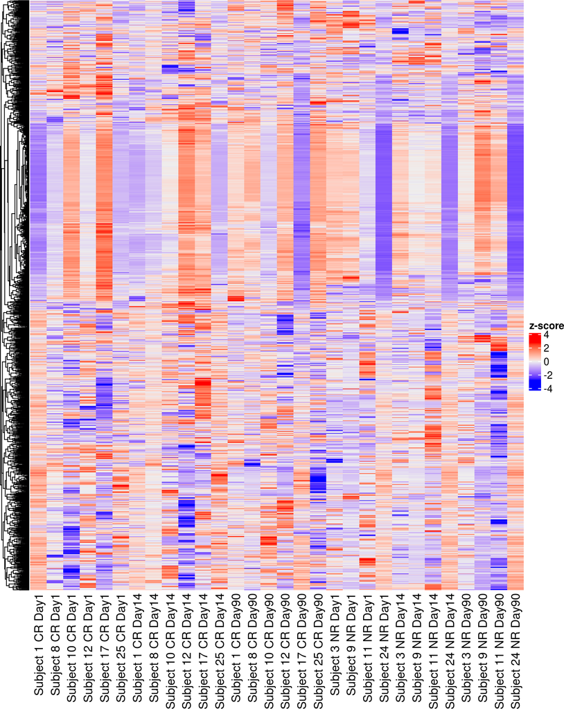

Figure 5: Heatmap of basophil data using z-scores  
As with the exosome data there isn’t a clear pattern between the groups.

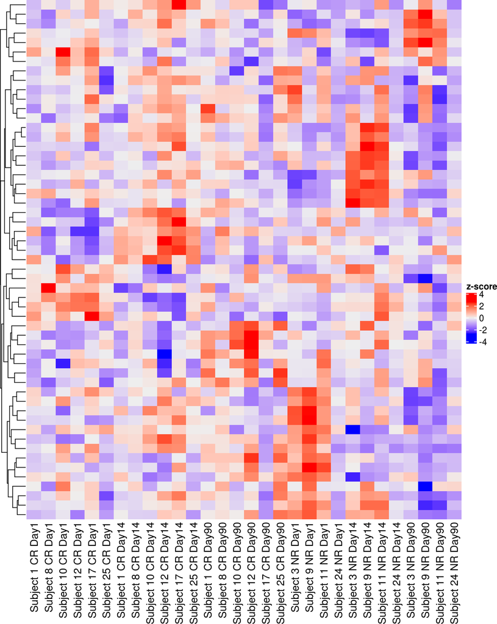

Figure 6: Heatmap of basophil data using z-scores, significant genes only  
When we subset to just the miRNAs that are significant in one or more contrasts, it is easier to see patterns of differential expression.

# References

Law, Charity W, Yunshun Chen, Wei Shi, and Gordon K Smyth. 2014. “Voom: Precision Weights Unlock Linear Model Analysis Tools for Rna-Seq Read Counts.” *Genome Biology* 15 (R29). https://doi.org/10.1186/gb-2014-15-2-r29.

Liu, R, AZ Holik, S Su, N Jansz, K Chen, HS Leong, ME Blewitt, ML Asselin-Labat, GK Smyth, and ME Ritchie. 2015. “Why Weight? Combining Voom with Estimates of Sample Quality Improves Power in Rna-Seq Analyses.” *NAR* 43: e97.

Phipson, Belinda, Stanley Lee, Ian J Majewski, Warren S Alexander, and Gordon K Smyth. 2016. “Robust Hyperparameter Estimation Protects Against Hypervariable Genes and Improves Power to Detect Differential Expression.” *The Annals of Applied Statistics* 10 (2): 946.